# Indel Signature InsDel_C

# InsDel_C

**Note**

InsDel_C looks somewhat similar to InsDel_13 in prominence of deletions of Ts that are followed by A. However, the 83-type and 476-type classifications show that InsDel13 has deletions of 2 Ts while InsDel_C has deletions of 1 T.

(corresponds to 83-type signature ID_C )

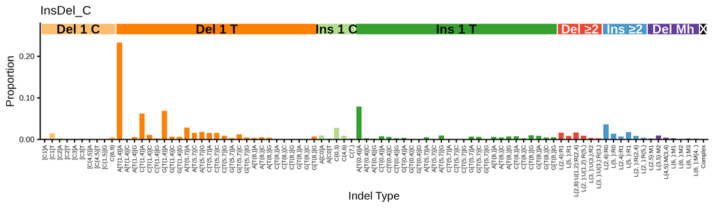

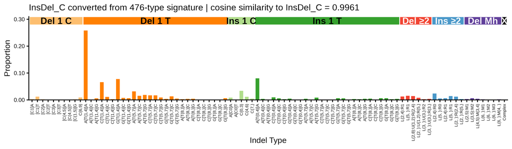

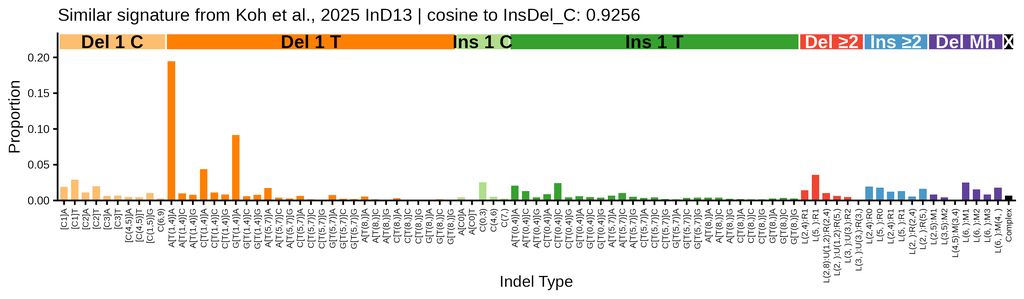

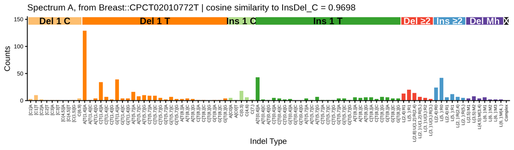

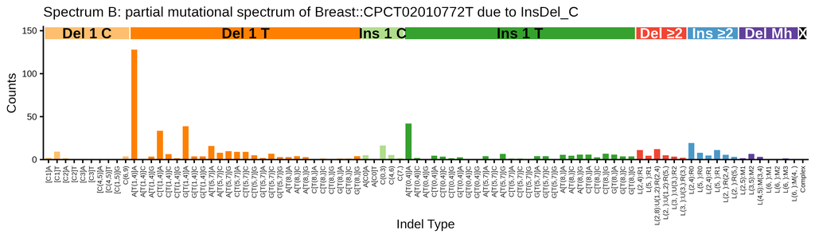

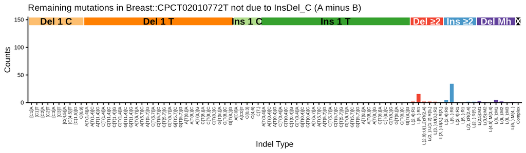

## 476-type representations corresponding to InsDel_C

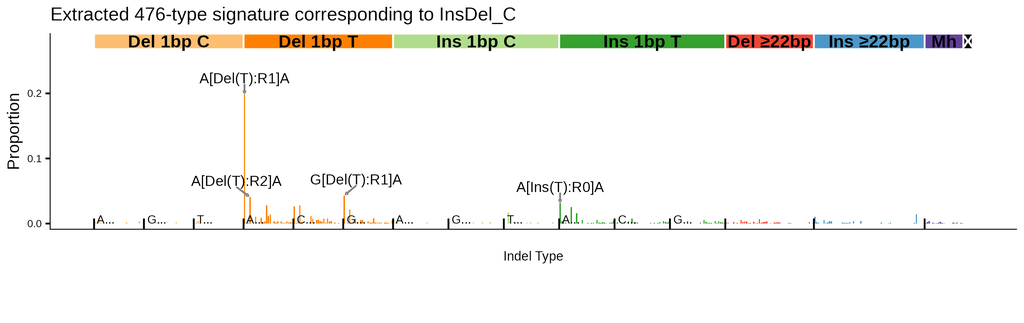

476-type spectrum of the supporting tumor Breast::CPCT02010772T; cosine similarity to the extracted 476-type signature is 0.9559

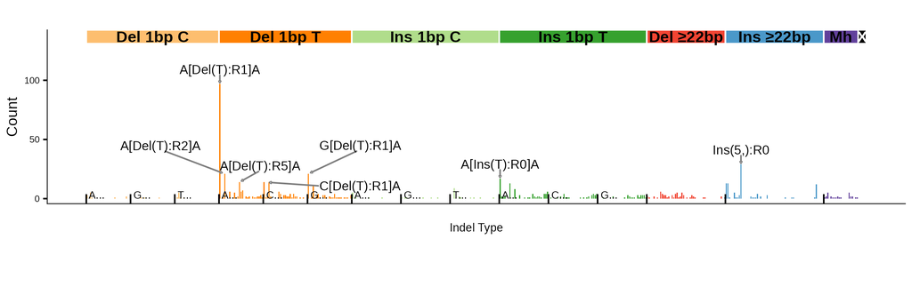

## 83-type signature corresponding to InsDel_C ( ID_C )

**Click here to show 83-type plots**

**Note**

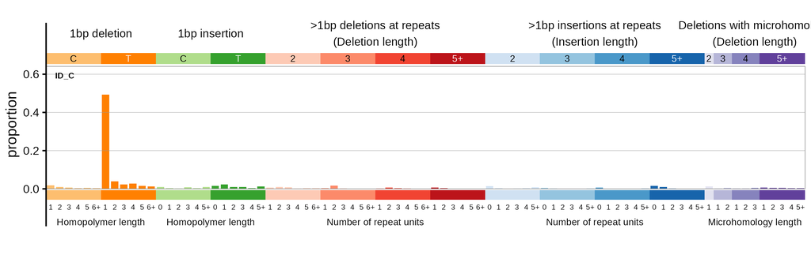

83-type signature converted from 476-type signature corresponding to InsDel_C | cosine similarity to ID_C: 0.8888

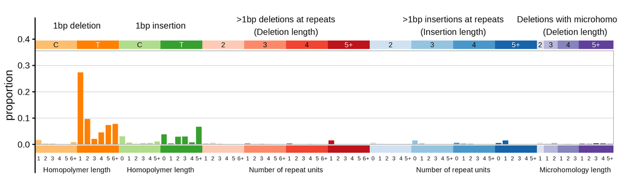

83-type spectrum of the supporting tumor Breast::CPCT02010772T | cosine similarly to ID_C: 0.8038

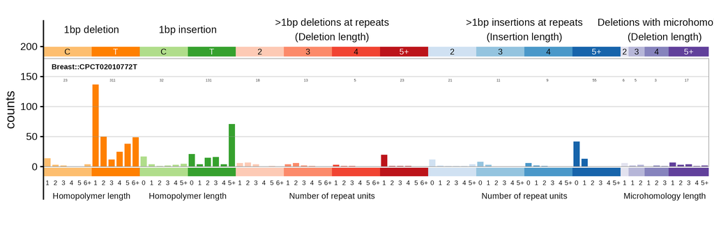